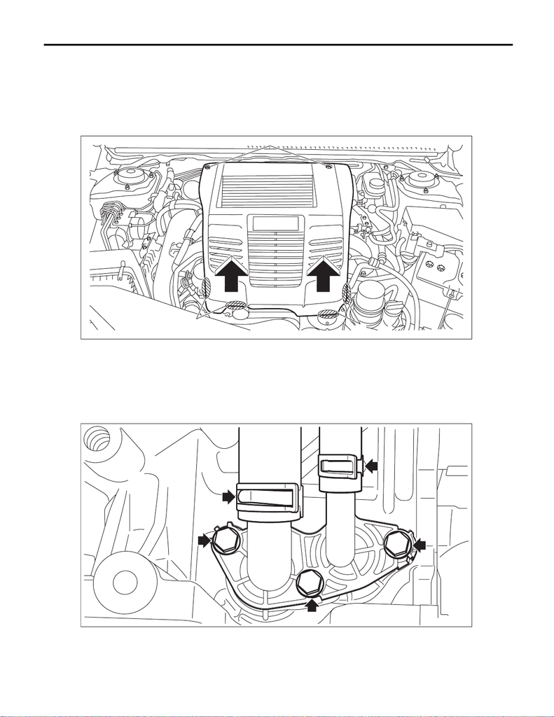

EC(w/o STI)-74

PCV Connector

EMISSION CONTROL (AUX. EMISSION CONTROL DEVICES)

14.PCV Connector

A: REMOVAL

1) Remove the collector cover.

(1) Remove the clips (A).

(2) Hold the shaded area (B) by hand and carefully pull the RH side (C) upward.

(3) Hold the shaded area (D) by hand and carefully pull the LH side (E) upward.

2) Collect the refrigerant from A/C system. <Ref. to AC-26, Refrigerant Recovery Procedure.>

3) Disconnect the ground terminal from battery sensor. <Ref. to NT-5, BATTERY, NOTE, Note.>

5) Remove the A/C compressor. <Ref. to AC-45, REMOVAL, Compressor.>

EX-03204

(A)

(B)

(C)

(E)

(D)

EC-03149

[figure not shown]

EC(w/o STI)-75

PCV Connector

EMISSION CONTROL (AUX. EMISSION CONTROL DEVICES)

B: INSTALLATION

Install in the reverse order of removal.

NOTE:

Use new O-rings.

Tightening torque:

6.4 N·m (0.7 kgf-m, 4.7 ft-lb)

C: INSPECTION

Check that the PCV connector has no deformation, cracks or other damages.